# Praca domowa 2

Paula Wołkowska

## Dane

Dane wykorzystane w Pracy domowej 2 opisują wycenę nieruchmości. Każda obserwacja jest pewną nieruchmością, która posiada informacje takie jak powierzchnia, liczba pokoi, liczba łazienek i wiele więcj. Opis wszystkich kolumn w pliku `README.md`.

## Zadanie 1

Jak wygląda rozkład ceny nieruchomości w poszczególnych kodach pocztowych na przestrzeni lat? Rozważamy kody pocztowe, które mają więcej niż 280 posiadłości.

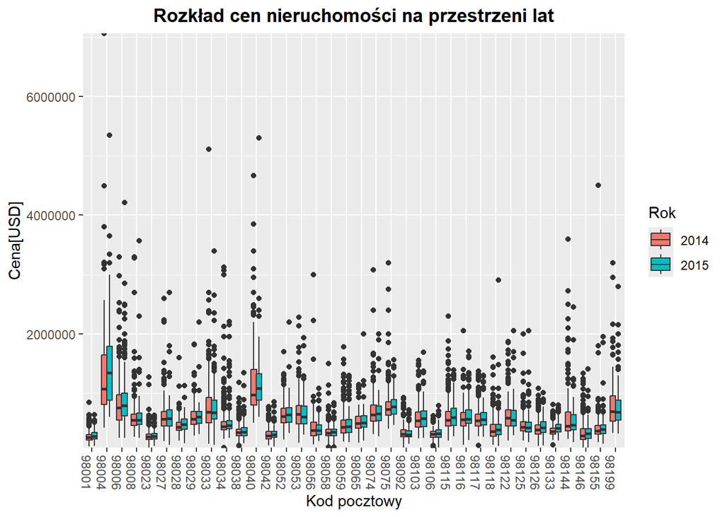

```r
df %>%
  mutate(date=as.Date(date, format = "%Y%m%dT%H%M%S"),
         year=format(date,"%Y")) %>%
  group_by(zipcode) %>%
  mutate(count=n()) %>%
  filter(count>280) %>%
  ungroup() %>%
  ggplot(aes(x=as.factor(zipcode),y=price,fill=as.factor(year)))+
  geom_boxplot(position = position_dodge(width = 0.7))+
  scale_y_continuous(expand=c(0,0))+
  labs(
    title="Rozkład cen nieruchomości na przestrzeni lat",
    x="Kod pocztowy",
    y="Cena[USD]",
    fill="Rok"
  )+
  theme(
    plot.title=element_text(hjust=0.5, face="bold"),
    axis.text.x=element_text(angle=-90)
  )
```

**Komentarz: Dla większości kodów pocztowych mediana cen nieruchomości wzrosła na przestrzeni lat.**

## Zadanie 2

Czy jest różnica w rozkładzie ceny nierchomości od powierzchni mieszkalnej uwzględniając podział na nieruchomości z piwnicą i bez?

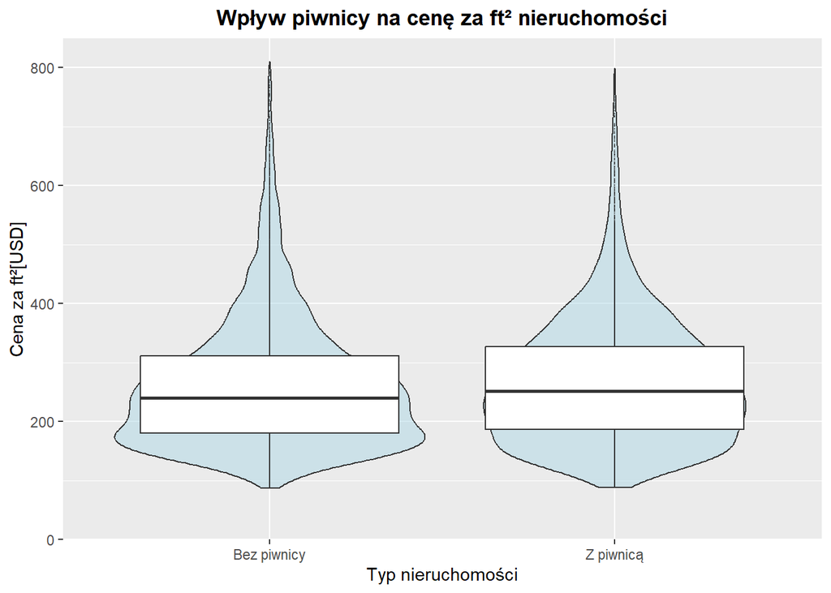

```r
df %>%
  mutate(has_basement=ifelse(sqft_basement==0, "Bez piwnicy", "Z piwnicą"),
         price_sqft=price/sqft_living) %>%
  ggplot(aes(x=has_basement, y=price_sqft))+
  geom_violin(fill="lightblue", alpha=0.5)+
  geom_boxplot(outlier.alpha=0.4, outlier.size=0)+
  scale_y_continuous(expand=c(0,0), limits=c(0,850))+
  labs(title="Wpływ piwnicy na cenę za ft² nieruchomości",
       x="Typ nieruchomości",
       y="Cena za ft²[USD]")+
  theme(
    plot.title=element_text(hjust=0.5, face="bold")
  )
```

**Komentarz: Tak, jest różnica w rozkładzie cen nieruchomości w przeliczeniu na powierzchnię mieszkalną (ft²) w zależności od posiadania piwnicy. Nieruchomości z piwnicą mają wyższe mediany cen za ft².**

## Zadanie 3

Jaka jest zależność pomiędzy jakością wykończenia nieruchomości a liczbą pięter?

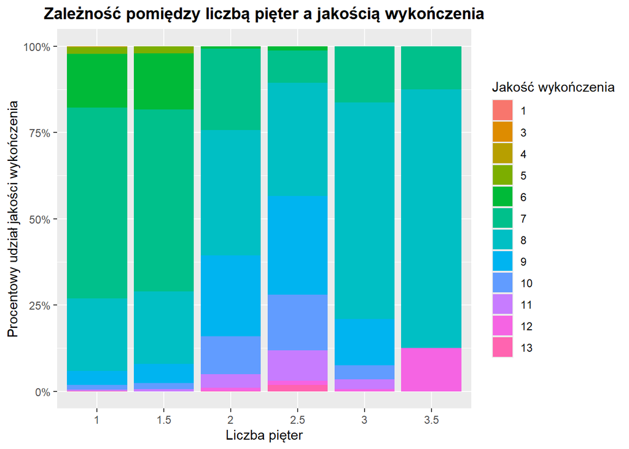

```r
df %>%
  ggplot(aes(x = as.factor(floors), fill = as.factor(grade))) +
  geom_bar(position = "fill") +
  scale_y_continuous(labels = scales::percent) +
  labs(
    title = "Zależność pomiędzy liczbą pięter a jakością wykończenia",
    x = "Liczba pięter",
    y = "Procentowy udział jakości wykończenia",
    fill = "Jakość wykończenia"
  ) +
  theme(
    plot.title = element_text(hjust = 0.5, face = "bold"),

  )
```

## Zadanie 4

Jaka jest zależność między powierzchnią mieszkalną nieruchomości a powierzchnią gruntu w podziale na liczbę sypialni?

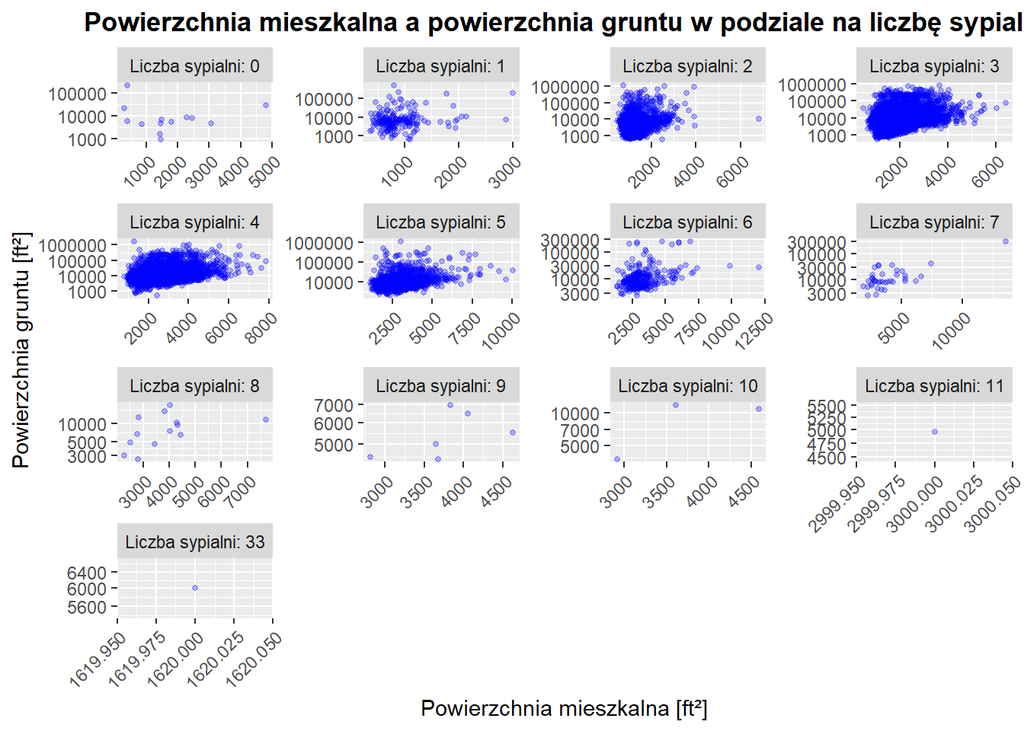

```r
df %>%
  ggplot(aes(x=sqft_living, y=sqft_lot))+
  geom_point(alpha=0.3, size=1, color="blue")+
  scale_y_log10()+
  facet_wrap(~bedrooms, ncol=4, scales="free",
             labeller = labeller(bedrooms = function(x) paste("Liczba sypialni:", x))
             )+
  labs(
    title="Powierzchnia mieszkalna a powierzchnia gruntu w podziale na liczbę sypialni",
    x="Powierzchnia mieszkalna [ft²]",
    y="Powierzchnia gruntu [ft²]",
  )+
  theme(
    plot.title=element_text(hjust=0.5, face="bold"),
    axis.text.x = element_text(angle = 45, hjust = 1)
  )
```

**Komentarz: Można wywnioskować, że zależność między powierzchnią mieszkalną a powierchnią gruntu jest bardziej widoczna dla niektórych liczby sypialni. Dla nieruchomości z 3-5 sypialniami widać tendencję wzrostową - większa powierzchnia mieszkalna zwykle wiążę się z wyższą powierznią działki. Dla pozostałych nieruchomości zależność jest mniej jednoznaczna.**

## Zadanie 5

Rozważmy tylko nieruchomości, które miały remont. W której dekadzie było najwięcej przeprowadzonych remontów? Czy w poszczególnych dekadach jest porównywalny procent nieruchmości dla każdej wartości miary jakości i wykończenia nieruchomości?

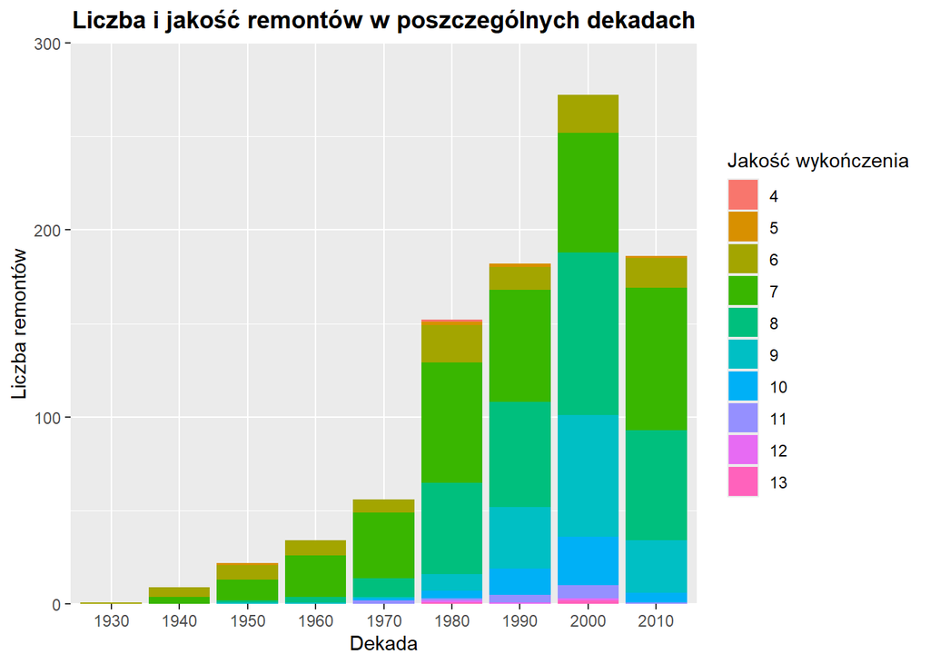

```r
df %>%
  filter(yr_renovated > 0) %>%
  mutate(
    date = as.Date(date, format = "%Y%m%dT%H%M%S"),
    renovation_decade = floor(yr_renovated / 10) * 10,
    grade = factor(grade, levels = sort(unique(grade)))
  ) %>%
  group_by(renovation_decade, grade) %>%
  summarise(cnt = n(), .groups = "drop") %>%
  group_by(renovation_decade) %>%
  ggplot(aes(x = as.factor(renovation_decade), y = cnt, fill = grade)) +
  geom_bar(stat = "identity", position = "stack") +
  labs(
    title = "Liczba i jakość remontów w poszczególnych dekadach",
    x = "Dekada",
    y = "Liczba remontów",
    fill = "Jakość wykończenia"
  ) +
  scale_y_continuous(expand = c(0, 0), limits = c(0, 300)) +
  theme(
    plot.title = element_text(hjust = 0.5, face = "bold")
  )
```

**Komentarz: Najwięcej remontów zostało przeprowadzonych w latach 2000-2009. W poszczególnych dekadach, procent nieruchomości dla każdej wartości miary jakości i wykończenia nieruchomości się różni.**

## Zadanie 6

Jak prezentuje się wartość minimalna, średnia i maksymalna ceny nieruchmości w podziele na rok budowy nieruchomości.

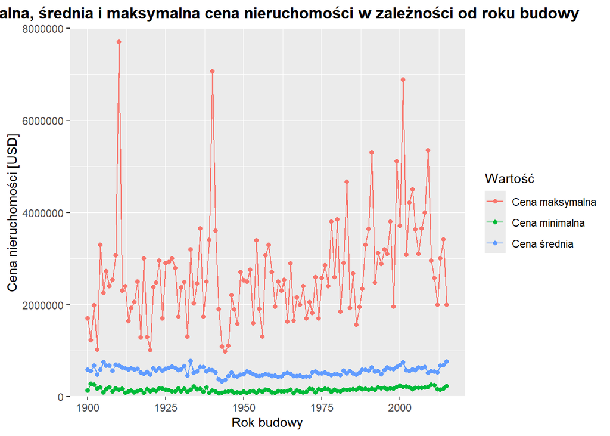

```r
df %>%
  group_by(yr_built) %>%
  summarise(min_price=min(price),
            avg_price=mean(price),
            max_price=max(price)) %>%
  ggplot(aes(x=yr_built))+
  geom_line(aes(y=min_price, color="Cena minimalna"))+
  geom_line(aes(y=avg_price, color="Cena średnia"))+
  geom_line(aes(y=max_price, color="Cena maksymalna"))+
  geom_point(aes(y=min_price, color="Cena minimalna"), size=1.5)+
  geom_point(aes(y=avg_price, color="Cena średnia"), size=1.5)+
  geom_point(aes(y=max_price, color="Cena maksymalna"), size=1.5)+
  scale_y_continuous(limits=c(0,8000000),expand=c(0,0))+
  labs(title="Minimalna, średnia i maksymalna cena nieruchomości w zależności od roku budowy",
       x="Rok budowy",
       y="Cena nieruchomości [USD]",
       color="Wartość")+
  theme(
    plot.title=element_text(hjust=0.5, face="bold")
  )
```

**Komentarz: Minimalne oraz średnie wartości ceny nieruchomości w zależności od roku budowy, utrzymują się na mniej więcej podobnym poziomie. Natomiast maksymalne ceny nieruchomości mogą się znacząco różnić na przestrzeni lat.**